# Retail Category Report: Story about Pasta, Pasta Sacue, Pancake Mixes and Syrup

Xi Wang

3/18/2019

# Overview of Transaction

These transactions tracked purchases over a two year period and total over 5197681 specific product purchases were recorded. Total 5197681 specific items purchases were recorded across 387 unique stores. A total of 927 different products within the four commodities were recorded during this time period.

|  | number_of_unique_values | number_of_missing_values |
| --- | --- | --- |
| upc | 927 | 0 |
| dollar_sales | 1502 | 0 |
| units | 49 | 0 |
| time_of_transaction | 1440 | 0 |
| geography | 2 | 0 |
| week | 104 | 0 |
| household | 510027 | 0 |
| store | 387 | 0 |
| basket | 3316349 | 0 |
| day | 726 | 0 |
| coupon | 2 | 0 |

## Week

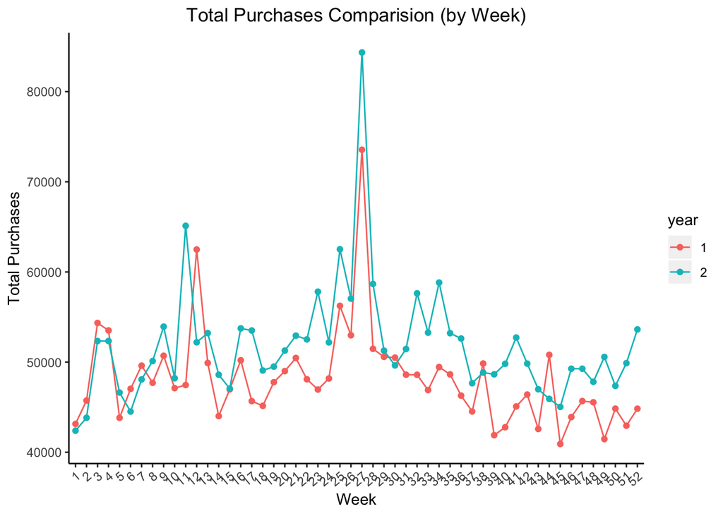

## State

The following table show the number of household in each state:

| state | total_household |
| --- | --- |
| GA | 233976 |
| KY | 112875 |
| TN | 109339 |
| SC | 23085 |
| AL | 15159 |
| IL | 12358 |
| IN | 10862 |

Each state shows consistency in items purchases in this two-year. The items purchase in GA, KY and TN are much higher than remaining states, which is also consistent with the number of household.

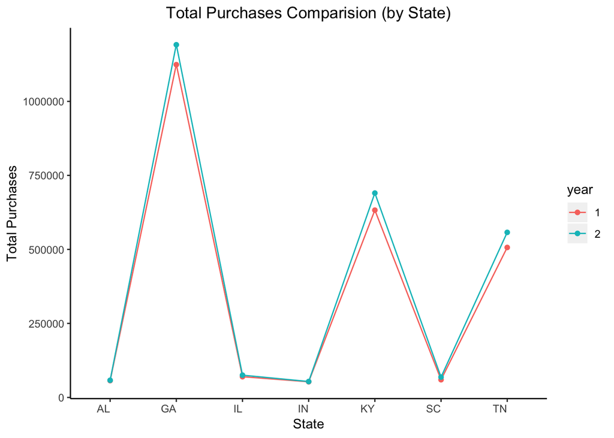

Through the deeper observations, we could find that in week 12, purchases in GA dropped greatly in second year. In week 27, purchases in KY and TN increased greatly.

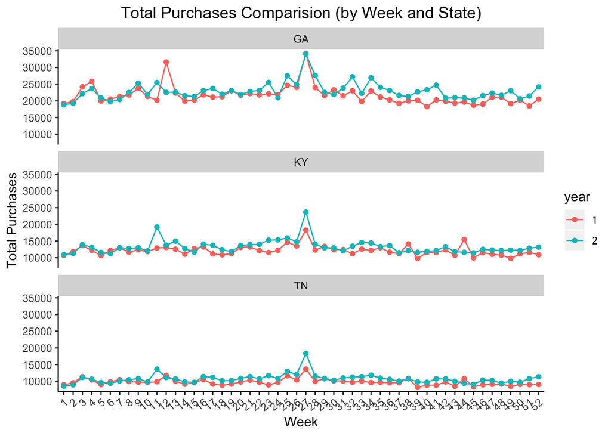

## Commodity

Each commodity shows consistency in items purchases in this two-year. The items purchase in pasta and pasta sauce are much higher than pancake mix and syrups.

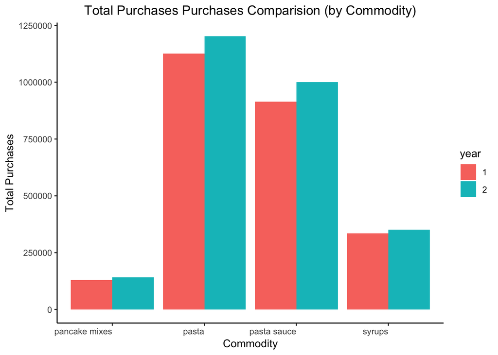

Shoppers purchased pasta and pasta sauce in preference to panckae and syrup arcoss states.

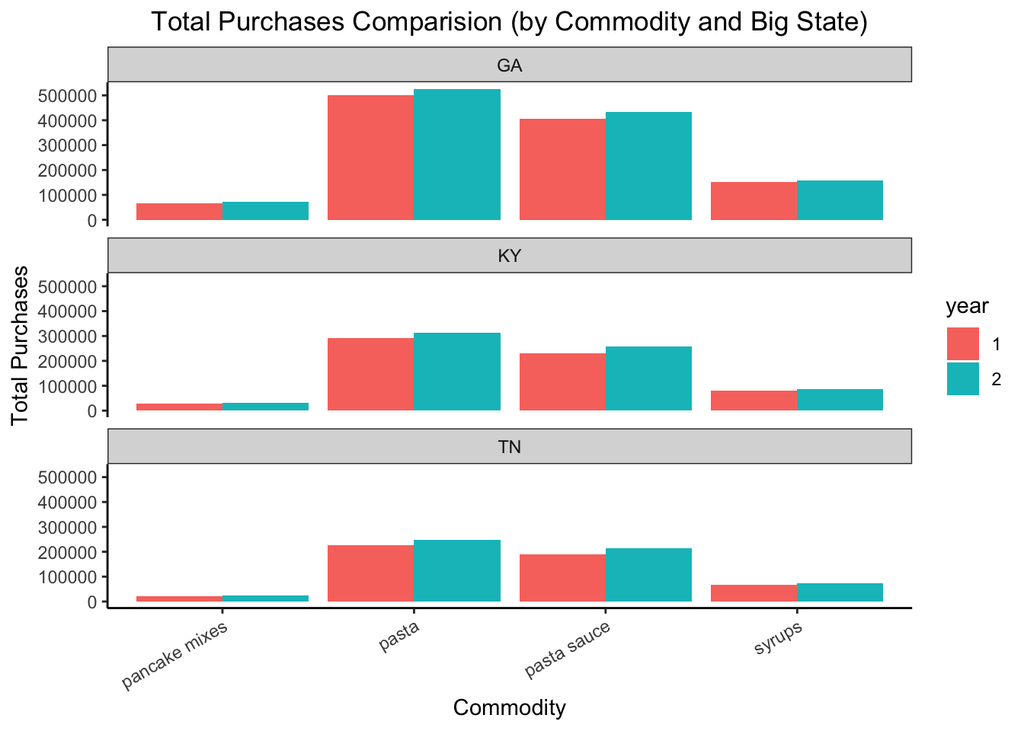

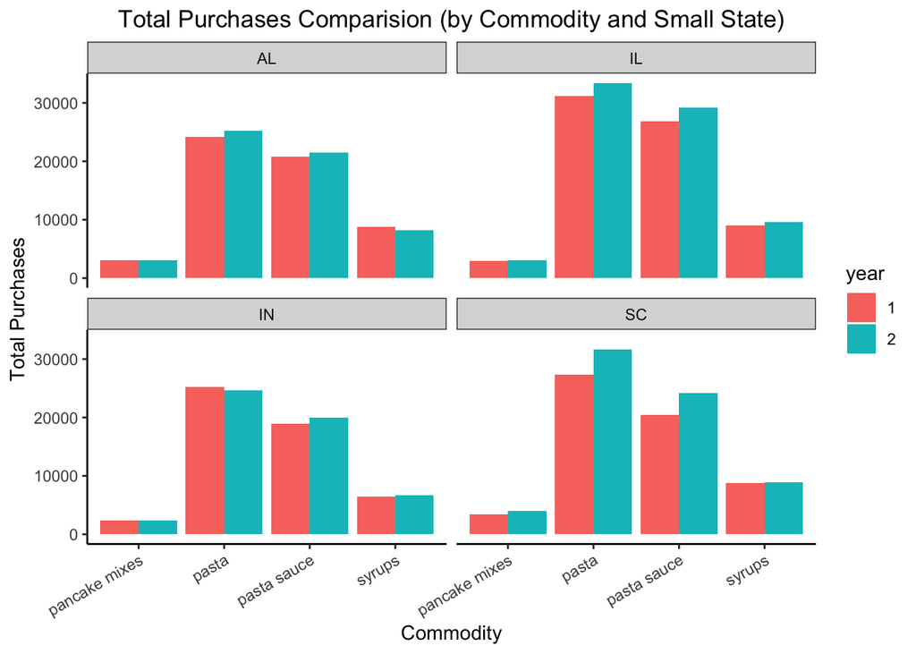

# Penetration

## Household Product Penetration

The household penetration of each product within each commodity shows us a simple view of preferences within our grocery shopper population. There are a total 510027 distinct households within this data set, and the following table shows how many distinct households within this total actually shopped in each of our four commodities.

| commodity | unique_household_count | percentage_household |
| --- | --- | --- |
| pasta | 411601 | 0.81 |
| pasta sauce | 362305 | 0.71 |
| syrups | 256514 | 0.50 |
| pancake mixes | 130580 | 0.26 |

## Pasta

The following table shows the product/brand penetration of the Pasta commodity group. It looks like our grocery shoppers are more price conscious within this area and that the Private Label manufacturers have a solid market share of the sales.

| brand | unique_household_count | percentage_household |
| --- | --- | --- |
| Private Label | 267358 | 0.52 |
| Barilla | 125579 | 0.25 |
| Mueller | 91128 | 0.18 |
| Creamette | 86672 | 0.17 |
| Private Label Premium | 76558 | 0.15 |

## Pasta Sauce

Contrary to the Pasta commodity finding, the Private Label brand does not have control of the market share within this group; it holds the third spot in which only about 25% of the shoppers that do buy pasta sauce tend to buy the Private Label brand. Since Pasta and Pasta Sauce do go hand in hand, the Private Label brand managers may have an opportunity within this area to do cross-commodity marketing.

| brand | unique_household_count | percentage_household |
| --- | --- | --- |
| Ragu | 207237 | 0.41 |
| Prego | 118132 | 0.23 |
| Private Label | 90754 | 0.18 |
| Hunt’s | 69509 | 0.14 |
| Classico | 58865 | 0.12 |

## Pancake Mixes

Similar with Pasta Sauce commodity finding, the Private Label brand does not have control of the market share within this group; it is the third place in which only about 25% of the shoppers that do buy pancake mixes do buy the Private Label brand. Some opportunites within this commodity could be grabbed.

| brand | unique_household_count | percentage_household |
| --- | --- | --- |
| Aunt Jemima | 56103 | 0.11 |
| Hungry Jack | 35557 | 0.07 |
| Private Label | 32199 | 0.06 |
| Krusteaz | 9241 | 0.02 |
| Bisquick | 7021 | 0.01 |

## Syrups

The Private Label dominates this commodity. Thus, Private Label brand managers may consider there are cross-commodity marketing opportunities within this area as well as within the Pasta and Pasta Sauce groups.

| brand | unique_household_count | percentage_household |
| --- | --- | --- |
| Private Label | 106181 | 0.21 |
| Aunt Jemima | 65654 | 0.13 |
| Karo | 30713 | 0.06 |
| Mrs Butterworth | 31809 | 0.06 |
| Northwoods | 29456 | 0.06 |

# Dollar Sales and Number of Purchases

## Commodity

Even though shoppers purchase pasta more than pasta sauce, the dollar sales of pasta sauce are much higher than pasta, given the unit price. Store managers may think about increasing shoppers chocies about pasata sauce. It is also the same case with syrups.

| commodity | total_purchases | total_units | total_sales | avg_pay | avg_unit_price |
| --- | --- | --- | --- | --- | --- |
| pasta sauce | 1913522 | 2313168 | 4025026.5 | 2.103465 | 1.740049 |
| pasta | 2327944 | 2880837 | 2851930.6 | 1.225086 | 0.989966 |
| syrups | 685918 | 724976 | 1741308.5 | 2.538654 | 2.401884 |
| pancake mixes | 270297 | 300646 | 511814.3 | 1.893526 | 1.702382 |

## Pasta

The following table shows top 5 pasta products (based on total sales). Products of Private label dominates this commodity. Shoppers do not favor the cheapest one. Pasta managers may pay more attentions on shoppers peference in pasta type rather than price.

| product_description | total_purchases | total_units | total_sales | avg_pay | avg_unit_price |
| --- | --- | --- | --- | --- | --- |
| PRIVATE LABEL SPAGHETTI REGULAR | 171884 | 215816 | 184111.72 | 1.0711394 | 0.8530958 |
| PRIVATE LABEL THIN SPAGHETTI | 173093 | 228331 | 148208.36 | 0.8562354 | 0.6490943 |
| PRIVATE LABEL ELBOW MACARONI | 99065 | 118911 | 123143.67 | 1.2430593 | 1.0355953 |
| PRIVATE LABEL ANGEL HAIR PASTA | 79920 | 111764 | 66160.21 | 0.8278305 | 0.5919635 |
| PRIVATE LABEL SPAGHETTI THIN | 46344 | 51599 | 61573.90 | 1.3286272 | 1.1933158 |

The following table show top 5 pasta brands (based on total sales), which is slight different from observations of penetration. Ronzoni is not in top 5 in penetration but has better dollar sales. Ronzoni managers should think about acquring more shoppers to increase penetration. Besides, almost half of purchases are generated by Private Label, which is greatly unbalanced.

| brand | total_purchases | purchase_percentage | total_units | total_sales | avg_pay | avg_unit_price |
| --- | --- | --- | --- | --- | --- | --- |
| Private Label | 998961 | 0.43 | 1269263 | 995201.3 | 0.9962363 | 0.7840781 |
| Barilla | 322649 | 0.14 | 394454 | 433764.8 | 1.3443859 | 1.0996587 |
| Creamette | 211008 | 0.09 | 254572 | 271543.3 | 1.2868863 | 1.0666661 |
| Mueller | 203244 | 0.09 | 250389 | 270701.2 | 1.3319027 | 1.0811227 |
| Ronzoni | 152712 | 0.07 | 188376 | 213566.5 | 1.3984918 | 1.1337245 |

The following table show top 3 pasta brands (based on total sales) across states. Private Label is a dominator. Barilla and Creamette also have great performance in most states. Mangers of them may think about expansion strategy in other states.

| state | brand | total_purchases | total_units | total_sales | avg_pay | avg_unit_price |
| --- | --- | --- | --- | --- | --- | --- |
| AL | Private Label | 23440 | 29334 | 21893.68 | 0.9340307 | 0.7463585 |
| AL | Barilla | 6708 | 7898 | 9315.96 | 1.3887835 | 1.1795341 |
| AL | Creamette | 5223 | 6102 | 7367.35 | 1.4105591 | 1.2073664 |
| GA | Private Label | 406191 | 523881 | 393146.53 | 0.9678859 | 0.7504501 |
| GA | Barilla | 155485 | 188829 | 221006.19 | 1.4213988 | 1.1704039 |
| GA | Mueller | 168400 | 207566 | 219824.06 | 1.3053685 | 1.0590562 |
| IL | Private Label | 34112 | 42532 | 35695.89 | 1.0464320 | 0.8392714 |
| IL | Creamette | 8383 | 10076 | 10837.77 | 1.2928272 | 1.0756024 |
| IL | Private Label Premium | 5900 | 6962 | 7164.53 | 1.2143271 | 1.0290908 |
| IN | Private Label | 24490 | 30777 | 25176.11 | 1.0280159 | 0.8180170 |
| IN | Creamette | 7353 | 8959 | 9332.62 | 1.2692262 | 1.0417033 |
| IN | San Giorgio | 5018 | 6128 | 6893.08 | 1.3736708 | 1.1248499 |
| KY | Private Label | 291819 | 364969 | 294950.79 | 1.0107320 | 0.8081530 |
| KY | Creamette | 94971 | 114579 | 120535.81 | 1.2691854 | 1.0519887 |
| KY | Barilla | 62346 | 77169 | 76964.50 | 1.2344737 | 0.9973500 |
| SC | Private Label | 22079 | 28161 | 21095.71 | 0.9554649 | 0.7491108 |
| SC | Barilla | 9702 | 11803 | 13735.80 | 1.4157699 | 1.1637550 |
| SC | Mueller | 9258 | 11357 | 12295.49 | 1.3280935 | 1.0826354 |
| TN | Private Label | 196830 | 249609 | 203242.55 | 1.0325791 | 0.8142437 |
| TN | Creamette | 94912 | 114645 | 123239.05 | 1.2984559 | 1.0749623 |
| TN | Barilla | 78263 | 96177 | 100013.11 | 1.2779105 | 1.0398859 |

The following geo-graph shows more details about pasta sales in different stores (based on zipcode):

[interactive chart not shown]

## Pasta Sauce

The following table show top 5 pasta sauce products (based on total sales).

| product_description | total_purchases | total_units | total_sales | avg_pay | avg_unit_price |
| --- | --- | --- | --- | --- | --- |
| RAGU TRADITIONAL PLAIN | 79305 | 100617 | 146471.95 | 1.846945 | 1.455738 |
| PREGO REG SPAGHETTI SAUCE | 58660 | 72940 | 125166.65 | 2.133765 | 1.716022 |
| RAGU OWS SPAG SAUCE MEAT | 48643 | 62756 | 89174.23 | 1.833239 | 1.420967 |
| PREGO MUSHROOM SPAG SAUCE | 34807 | 41153 | 84147.56 | 2.417547 | 2.044749 |
| RAGU SPAGH SAUCE PLAIN | 24508 | 28335 | 80414.19 | 3.281140 | 2.837981 |

The following table show top 5 pasta sauce brands (based on total sales).Private Label is the fourth place. The Private Label brand managers may have an opportunity within this area to do cross-commodity marketing. Besides, Bertolli managers may consider acquring more new shoppers to increase penetration.

| brand | total_purchases | purchase_percentage | total_units | total_sales | avg_pay | avg_unit_price |
| --- | --- | --- | --- | --- | --- | --- |
| Ragu | 738294 | 0.39 | 891433 | 1500754.6 | 2.032733 | 1.683530 |
| Prego | 342971 | 0.18 | 402897 | 799932.2 | 2.332361 | 1.985451 |
| Classico | 148032 | 0.08 | 172242 | 438178.5 | 2.960025 | 2.543970 |
| Private Label | 245385 | 0.13 | 306059 | 331062.4 | 1.349155 | 1.081695 |
| Bertolli | 84905 | 0.04 | 97379 | 258090.8 | 3.039760 | 2.650375 |

The following table show top 3 pasta sauce brands (based on total sales) across states. The Private Label brand managers should pay attentions to GA,KY,and TN market, where have amount of pasta shoppers, but shoppers there do not favor Private Label pasta sauce.

| state | brand | total_purchases | total_units | total_sales | avg_pay | avg_unit_price |
| --- | --- | --- | --- | --- | --- | --- |
| AL | Ragu | 16076 | 19003 | 31434.15 | 1.955347 | 1.654168 |
| AL | Prego | 7506 | 8449 | 16414.21 | 2.186812 | 1.942740 |
| AL | Private Label | 7449 | 9381 | 9699.15 | 1.302074 | 1.033914 |
| GA | Ragu | 312983 | 369749 | 636282.61 | 2.032962 | 1.720850 |
| GA | Prego | 155985 | 179089 | 352789.17 | 2.261687 | 1.969910 |
| GA | Classico | 73215 | 85273 | 211950.30 | 2.894903 | 2.485550 |
| IL | Ragu | 22390 | 28744 | 46191.26 | 2.063031 | 1.606988 |
| IL | Prego | 9609 | 12050 | 24188.26 | 2.517250 | 2.007325 |
| IL | Private Label | 7960 | 10474 | 10645.97 | 1.337433 | 1.016419 |
| IN | Ragu | 15431 | 19463 | 31835.84 | 2.063109 | 1.635711 |
| IN | Prego | 8039 | 9859 | 19737.25 | 2.455187 | 2.001952 |
| IN | Classico | 2072 | 2392 | 6339.34 | 3.059527 | 2.650226 |
| KY | Ragu | 197233 | 243808 | 401958.72 | 2.037989 | 1.648669 |
| KY | Prego | 91291 | 110456 | 223141.09 | 2.444284 | 2.020181 |
| KY | Classico | 30644 | 35502 | 94109.73 | 3.071066 | 2.650829 |
| SC | Ragu | 15947 | 19129 | 32404.88 | 2.032036 | 1.694019 |
| SC | Prego | 7843 | 8991 | 17687.40 | 2.255183 | 1.967234 |
| SC | Classico | 4254 | 5097 | 12742.88 | 2.995505 | 2.500075 |
| TN | Ragu | 158234 | 191537 | 320647.12 | 2.026411 | 1.674074 |
| TN | Prego | 62698 | 74003 | 145974.85 | 2.328222 | 1.972553 |
| TN | Classico | 32544 | 37800 | 97657.40 | 3.000780 | 2.583529 |

The following geo-graph shows more details about pasta sauce sales in different stores (based on zipcode):

[interactive chart not shown]

## Pancake Mixes

The following table show top 5 pancake mix products (based on total sales).

| product_description | total_purchases | total_units | total_sales | avg_pay | avg_unit_price |
| --- | --- | --- | --- | --- | --- |
| AJ BUTTERMILK PANCAKE MIX | 43462 | 45595 | 93321.06 | 2.147187 | 2.046739 |
| PRIVATE LABEL COMPLETE PANCAKE MIX | 52095 | 58396 | 73616.82 | 1.413126 | 1.260648 |
| AUNT JEM ORIGINAL PANCAKE MIX | 25542 | 26759 | 55974.63 | 2.191474 | 2.091806 |
| A/JEM COMPLETE PANCAKE MI | 22829 | 23963 | 50030.20 | 2.191520 | 2.087810 |
| H J PANCK BTRMLK COMP MIX | 21504 | 22569 | 44004.65 | 2.046347 | 1.949783 |

The following table show top 5 pancake mix brands (based on total sales). Aunt Jemima is a solid dominator in this area. Private Label managers may think about differentiation strategy to earn the market share.

| brand | total_purchases | purchase_percentage | total_units | total_sales | avg_pay | avg_unit_price |
| --- | --- | --- | --- | --- | --- | --- |
| Aunt Jemima | 97264 | 0.36 | 101853 | 206698.12 | 2.125125 | 2.029377 |
| Hungry Jack | 54633 | 0.20 | 57016 | 111435.32 | 2.039707 | 1.954457 |
| Private Label | 52095 | 0.19 | 58396 | 73616.82 | 1.413126 | 1.260648 |
| Krusteaz | 13910 | 0.05 | 14796 | 30528.77 | 2.194735 | 2.063312 |
| Bisquick | 12674 | 0.05 | 17675 | 18437.72 | 1.454767 | 1.043152 |

The following table show top 3 pancake mix brands (based on total sales) across states. The ranking is surprisingly consistent across states. Other brands face great challenges in this commodity. Thus other brands managers may think about starting the challenge in one or two states instead of competing in every states.

| state | brand | total_purchases | total_units | total_sales | avg_pay | avg_unit_price |
| --- | --- | --- | --- | --- | --- | --- |
| AL | Aunt Jemima | 2002 | 2080 | 4129.48 | 2.062677 | 1.985327 |
| AL | Hungry Jack | 1177 | 1231 | 2222.45 | 1.888233 | 1.805402 |
| AL | Private Label | 1372 | 1506 | 1852.83 | 1.350459 | 1.230299 |
| GA | Aunt Jemima | 53833 | 56894 | 112964.53 | 2.098425 | 1.985526 |
| GA | Hungry Jack | 25108 | 26233 | 51116.34 | 2.035859 | 1.948551 |
| GA | Private Label | 25231 | 28705 | 36021.29 | 1.427660 | 1.254879 |
| IL | Aunt Jemima | 1584 | 1639 | 3571.41 | 2.254678 | 2.179018 |
| IL | Hungry Jack | 1366 | 1419 | 2947.00 | 2.157394 | 2.076815 |
| IL | Private Label | 1635 | 1748 | 2284.58 | 1.397297 | 1.306968 |
| IN | Aunt Jemima | 1536 | 1578 | 3467.17 | 2.257272 | 2.197193 |
| IN | Hungry Jack | 1010 | 1064 | 2116.38 | 2.095426 | 1.989079 |
| IN | Private Label | 1011 | 1154 | 1505.30 | 1.488922 | 1.304419 |
| KY | Aunt Jemima | 17566 | 18137 | 39452.10 | 2.245935 | 2.175227 |
| KY | Hungry Jack | 14348 | 14854 | 29900.65 | 2.083959 | 2.012970 |
| KY | Private Label | 12796 | 14020 | 17920.14 | 1.400449 | 1.278184 |
| SC | Aunt Jemima | 2602 | 2724 | 5399.61 | 2.075177 | 1.982236 |
| SC | Hungry Jack | 1183 | 1215 | 2410.56 | 2.037667 | 1.984000 |
| SC | Private Label | 1472 | 1732 | 2115.77 | 1.437344 | 1.221576 |
| TN | Aunt Jemima | 18141 | 18801 | 37713.82 | 2.078927 | 2.005948 |
| TN | Hungry Jack | 10441 | 11000 | 20721.94 | 1.984670 | 1.883813 |
| TN | Private Label | 8578 | 9531 | 11916.91 | 1.389241 | 1.250331 |

The following geo-graph shows more details about pancake mix sales in different stores (based on zipcode):

[interactive chart not shown]

## Syrups

The following table show top 5 syrups products (based on total sales).

| product_description | total_purchases | total_units | total_sales | avg_pay | avg_unit_price |
| --- | --- | --- | --- | --- | --- |
| AUNT JEMIMA ORIGINL SYRUP | 31765 | 32385 | 98922.68 | 3.114204 | 3.054583 |
| PRIVATE LABEL SYRUP PLASTIC BOTTLE | 59460 | 64553 | 96146.78 | 1.616999 | 1.489424 |
| MRS BUTTERWORTH SYRUP | 28669 | 29468 | 86863.46 | 3.029874 | 2.947722 |
| AUNT JEMIMA LITE SYRUP | 19372 | 19884 | 67371.03 | 3.477753 | 3.388203 |
| PRIVATE LABEL MAPLE SYRUP | 14164 | 15463 | 66622.01 | 4.703615 | 4.308479 |

The following table show top 5 syrups brands (based on total sales). Private Label is neck to neck with Aunt Jemima. Aunt Jemima managers should consider increasing penetration to boost the total purchases. The same advise for Log Cabin, since their penetration has potential to be increased.

| brand | total_purchases | purchase_percentage | total_units | total_sales | avg_pay | avg_unit_price |
| --- | --- | --- | --- | --- | --- | --- |
| Aunt Jemima | 120901 | 0.18 | 123938 | 359668.9 | 2.974904 | 2.902007 |
| Private Label | 206115 | 0.30 | 222524 | 352930.9 | 1.712301 | 1.586035 |
| Mrs Butterworth | 51197 | 0.07 | 52596 | 159165.5 | 3.108883 | 3.026190 |
| Log Cabin | 41172 | 0.06 | 42503 | 130904.4 | 3.179453 | 3.079887 |
| Karo | 47488 | 0.07 | 52004 | 120431.0 | 2.536030 | 2.315802 |

The following table show top 3 syrups brands (based on total sales) across states.Aunt Jemima should pay more attentions to IL market, since it is neck to neck with Mrs Butterworth.

| state | brand | total_purchases | total_units | total_sales | avg_pay | avg_unit_price |
| --- | --- | --- | --- | --- | --- | --- |
| AL | Private Label | 5002 | 5393 | 8762.19 | 1.751737 | 1.624734 |
| AL | Aunt Jemima | 2960 | 3052 | 8672.49 | 2.929895 | 2.841576 |
| AL | Karo | 1692 | 1877 | 3934.77 | 2.325514 | 2.096308 |
| GA | Aunt Jemima | 70145 | 71717 | 200190.77 | 2.853956 | 2.791399 |
| GA | Private Label | 80884 | 88639 | 142815.21 | 1.765679 | 1.611201 |
| GA | Northwoods | 43148 | 45022 | 79111.65 | 1.833495 | 1.757178 |
| IL | Private Label | 6854 | 7367 | 11445.80 | 1.669945 | 1.553658 |
| IL | Mrs Butterworth | 2039 | 2098 | 6610.53 | 3.242045 | 3.150872 |
| IL | Aunt Jemima | 1848 | 1945 | 6103.60 | 3.302814 | 3.138098 |
| IN | Private Label | 4432 | 4724 | 7114.83 | 1.605332 | 1.506103 |
| IN | Aunt Jemima | 1493 | 1552 | 4950.85 | 3.316041 | 3.189981 |
| IN | Mrs Butterworth | 1211 | 1238 | 3877.39 | 3.201808 | 3.131979 |
| KY | Private Label | 58257 | 62051 | 95525.54 | 1.639726 | 1.539468 |
| KY | Aunt Jemima | 19065 | 19582 | 61451.28 | 3.223251 | 3.138151 |
| KY | Mrs Butterworth | 15682 | 16165 | 50077.33 | 3.193300 | 3.097886 |
| SC | Aunt Jemima | 3740 | 3830 | 10575.88 | 2.827775 | 2.761326 |
| SC | Private Label | 4933 | 5561 | 8727.10 | 1.769126 | 1.569340 |
| SC | Log Cabin | 1197 | 1220 | 3588.95 | 2.998287 | 2.941762 |
| TN | Private Label | 45753 | 48789 | 78540.19 | 1.716613 | 1.609793 |
| TN | Aunt Jemima | 21650 | 22260 | 67724.05 | 3.128132 | 3.042410 |
| TN | Mrs Butterworth | 10945 | 11186 | 33833.17 | 3.091199 | 3.024599 |

The following geo-graph shows more details about syrups sales in different stores (based on zipcode):

[interactive chart not shown]

# Repeat Purchase Rate

The formula for repeat purchase rate is: $ The number of repeat customers/ The number of total customers $

## Pasta

Repeat purchase rate for pasta is 0.65. Each shopper purchase pasta averagely 5.

We consider shoppers who purchase more than the 5 are frequent shoppers. Following table shows top 5 brands with most percentage of frequent shoppers. Dollar sales of Mlinotst and Private Label heavily rely on frequent shoppers.

| brand | frequent_percentage | sales_percentage |
| --- | --- | --- |
| Mlinotst | 0.33 | 0.79 |
| Private Label | 0.21 | 0.59 |
| China Mandarin | 0.14 | 0.30 |
| Barilla | 0.10 | 0.40 |
| Creamette | 0.10 | 0.38 |

## Pasta Sauce

Repeat purchase rate for pasta_sauce is 0.62.Each shopper purchase pasta averagely 5.

We consider shoppers who purchase more than the 5 are frequent shoppers. Following table shows top 5 brands with most percentage of frequent shoppers.Even though the percentage of frequent shoppers is not higt, the sales are still heavily rely on them.

| brand | frequent_percentage | sales_percentage |
| --- | --- | --- |
| Ragu | 0.17 | 0.54 |
| Prego | 0.12 | 0.47 |
| Hunt’s | 0.10 | 0.39 |
| Private Label | 0.10 | 0.38 |
| Chef Pizza | 0.09 | 0.43 |

## Pancake Mixes

Repeat purchase rate for pancake_mix is 0.39. Each shopper purchase pancake mixes averagely 3.

We consider shoppers who purchase more than the 3 are frequent shoppers. Following table shows top 5 brands with most percentage of frequent shoppers. Even though the percentage of frequent shoppers is not higt, the sales are still heavily rely on them.

| brand | frequent_percentage | sales_percentage |
| --- | --- | --- |
| Classique | 0.16 | 0.55 |
| Aunt Jemima | 0.15 | 0.42 |
| Bisquick | 0.15 | 0.46 |
| Bruce’s | 0.15 | 0.50 |
| White Lily | 0.14 | 0.49 |

## Syrups

Repeat purchase rate for syrups is 0.49.Each shopper purchase syrups averagely 3.

We consider shoppers who purchase more than the 3 are frequent shoppers. Following table shows top 5 brands with most percentage frequent shoppers. Even though the percentage of frequent shoppers is not higt, the sales are still heavily rely on them.

| brand | frequent_percentage | sales_percentage |
| --- | --- | --- |
| Tree of Life | 0.33 | 0.54 |
| Private Label | 0.18 | 0.49 |
| Aunt Jemima | 0.15 | 0.47 |
| Hungry Jack | 0.15 | 0.48 |
| Log Cabin | 0.14 | 0.44 |

Generally, most shoppers repeatly purchase pasta and pasta sauce,and their repeat purchase rate is similar. But shoppers purchaes syrups more repeatly than panckae mixes. It suggests that shoppers consume syrups faster than pancake mixes, which provide a great opportunity for syrups brands. Through observations on frequent shoppers arcoss brands for each commodity, they make great contributions to sales.

# Coupon Users

| commodity | total_coupon_users | user_percentage |
| --- | --- | --- |
| pancake mixes | 4067 | 0.03 |
| pasta | 11875 | 0.03 |
| pasta sauce | 24983 | 0.06 |
| syrups | 13935 | 0.05 |

## Coupons Users vs. Frequent Shoppers

### Pasta

For pasta purchase, this suggests that coupon usage will lead to frequent purchase although further studies are required to confirm this.

```
##
##  Pearson's Chi-squared test with Yates' continuity correction
##
## data:  pasta_table
## X-squared = 1769, df = 1, p-value < 0.00000000000000022
```

### Pasta Sauce

For pasta sauce purchase, this suggests that coupon usage will not lead to frequent purchase although further studies are required to confirm this.

```
##
##  Pearson's Chi-squared test with Yates' continuity correction
##
## data:  pasta_sauce_table
## X-squared = 1.944, df = 1, p-value = 0.1632
```

### Pancake Mixes

For pancake mixes purchase, this suggests that coupon usage will lead to frequent purchase although further studies are required to confirm this.

```
##
##  Pearson's Chi-squared test with Yates' continuity correction
##
## data:  pancake_mix_table
## X-squared = 3.9119, df = 1, p-value = 0.04795
```

### Syrups

For syrups purchase, this suggests that coupon usage will lead to frequent purchase although further studies are required to confirm this.

```
##
##  Pearson's Chi-squared test with Yates' continuity correction
##
## data:  syrups_table
## X-squared = 141.76, df = 1, p-value < 0.00000000000000022
```

In short, coupon usages do lead to frequent purchases for most commodities.

# Purchase Together

The following graph is top 20 frequent purchase brands.

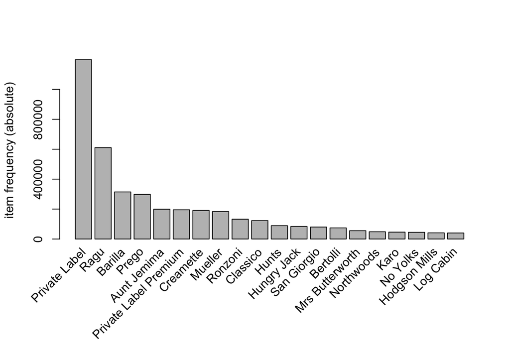

Since most brands cover multiple commoditis, we picked three brands based on previous analysis to observe what other brands are frequently purchased with them together.

## Private Label

|  | lhs |  | rhs | support | confidence | lift | count |
| --- | --- | --- | --- | --- | --- | --- | --- |
| [1] | {} | => | {Private Label} | 0.3613361 | 0.3613361 | 1.0000000 | 1198317 |
| [2] | {Prego} | => | {Private Label} | 0.0247064 | 0.2746059 | 0.7599737 | 81935 |
| [3] | {Barilla} | => | {Private Label} | 0.0108137 | 0.1139989 | 0.3154927 | 35862 |

## Ragu

For Ragu, associated brands are {Mueller} and {Creamette}.

|  | lhs |  | rhs | support | confidence | lift | count |
| --- | --- | --- | --- | --- | --- | --- | --- |
| [1] | {Mueller} | => | {Ragu} | 0.0120189 | 0.2173894 | 1.180623 | 39859 |
| [2] | {Creamette} | => | {Ragu} | 0.0112033 | 0.1944472 | 1.056026 | 37154 |
| [3] | {} | => | {Ragu} | 0.1841310 | 0.1841310 | 1.000000 | 610643 |

## Aunt Jemima

For Aunt Jemima, associated brands are {Mueller} and {Creamette}.

[output not shown]